# Cupom Coletor e Paradoxo do Aniversário

```r
#Pacotes utilizados
library(ggplot2)
#seed fixa
set.seed(123)
```

**Introdução**

Neste projeto estudaremos dois problemas de probabilidade clássicos, o cupom-coletor e o paradoxo do aniversário. O objetivo do trabalho é utilizar técnicas de programação para simular em grandes iterações e diferentes métricas os problemas, e visa coletar resultados empíricos e comparar com os resultados teóricos.

**Cupom-coletor**

Neste problema, o colecionador de cupons tem como objetivo completar o seu “álbum”. No contexto, o colecionador realiza sorteios com reposição dos itens do álbum até completar a sua coleção. A pegunta para este problema é “espera-se quantos sorteios com reposição para completar todos os itens da coleção?”

**Simulação: Cupom-coletor**

Considere um álbum com $N$ itens distintos. Em cada passo, um itens será sorteado do conjunto, sendo que cada item tem probabilidade $1/N$ de ser escolhido. O item é reposto e o sorteio é feito novamente. O processo continua até que todos os $N$ itens é observado pelo menos uma vez, ou seja, o “álbum é completado”. A variável de interesse é o número de sorteios necessários $T_n$.

```r
CupCol <- function(N){
  aux <- c() #vetor auxiliar para armazenar os itens já sorteados
  Tn <- 0 #para contar o número de sorteios realizados

  while(length(aux) < N){ #loop até completar o álbum
    Tn <- Tn + 1 #contagem dos sorteios
    i <- sample(1:N, 1) #sorteio de um item com probabilidades iguais

    if(i %in% aux){ #verifica se o item já foi observado
      next #pula para próxima iteração
    }
    else{ #se o item não foi observado ainda
      aux <- c(aux, i) # adiciona o item no vetor aux
    }
  }
  return(Tn) #retorna o numero de sorteios feitos
}
```

Acima, escrevemos uma função o qual simula o problema do cupom-coletor, com parâmetro $N$. Podemos simular o problema com diferentes $N$s.

```r
CupCol(N = 50)
```

```
[1] 129
```

```r
CupCol(N = 100)
```

```
[1] 316
```

```r
CupCol(N = 200)
```

```
[1] 2082
```

```r
CupCol(N = 500)
```

```
[1] 3034
```

Vamos realizar $M = 5000$ réplicas para cada $N$.

```r
replicador <- function(M, N){
  aux <- c()
  for(i in 1:M){ #faz M iteracoes do processo
    x <- CupCol(N) #chama a função
    aux <- c(aux, x) #armazena o valor x em um vetor
  }
  return(aux)#retorna o vetor com os M numeros de sorteios

}
```

```r
#M = 5000 para todo N
A50 <- replicador(5000, 50) #N=50
A100 <- replicador(5000, 100) #N=100
A200 <- replicador(5000, 200) #N=200
A500 <- replicador(5000, 500) #N=500
```

Assim, podemos encontrar a média, a variância e distribuição empírica das simulações:

```r
#Tabela de Médias e Variancias para cada N (empírico)
Num <- c("50", "100", "200", "500")
medias_emp <- c(mean(A50), mean(A100), mean(A200), mean(A500))
variancias_emp <- c(var(A50), var(A100), var(A200), var(A500))

tabela_emp <- data.frame(
  N = Num,
  Média = round(medias_emp, 2),
  Variância = round(variancias_emp, 2)
)

print(tabela_emp)
```

| N | Média | Variância |
| --- | --- | --- |
| 50 | 225.14 | 3909.20 |
| 100 | 520.10 | 15751.10 |
| 200 | 1181.65 | 66575.11 |
| 500 | 3397.41 | 415122.04 |

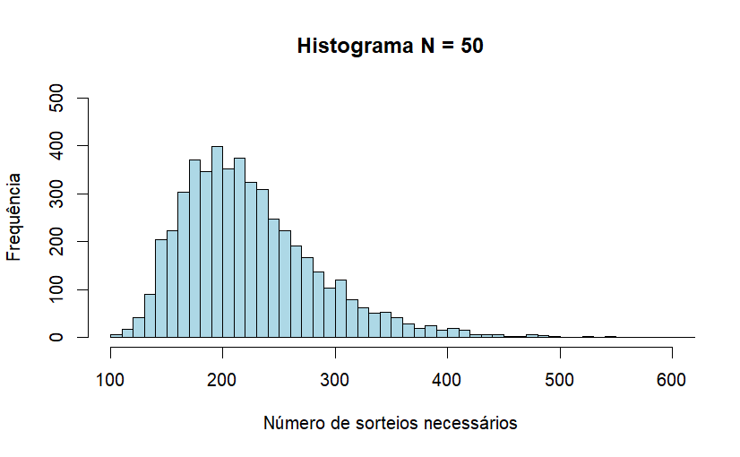

```r
h_emp_50 <- hist(A50,
     main = "Histograma N = 50",
     xlab = "Número de sorteios necessários",
     ylab = "Frequência",
     col = "lightblue",
     border = "black",
     breaks = 50,
     xlim = c(100, 600),
     ylim = c(0, 500))
```

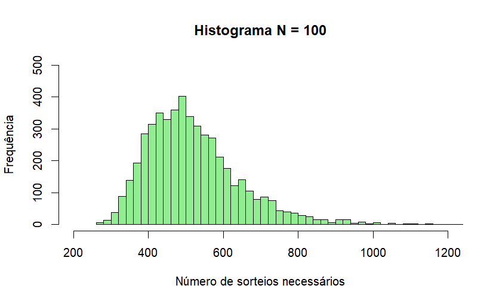

```r
h_emp_100 <- hist(A100,
     main = "Histograma N = 100",
     xlab = "Número de sorteios necessários",
     ylab = "Frequência",
     col = "lightgreen",
     border = "black",
     breaks = 50,
     xlim = c(200, 1200),
     ylim = c(0, 500))
```

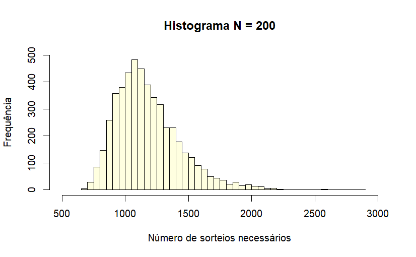

```r
h_emp_200 <- hist(A200,
     main = "Histograma N = 200",
     xlab = "Número de sorteios necessários",
     ylab = "Frequência",
     col = "lightyellow",
     border = "black",
     breaks = 50,
     xlim = c(500, 3000),
     ylim = c(0, 500))
```

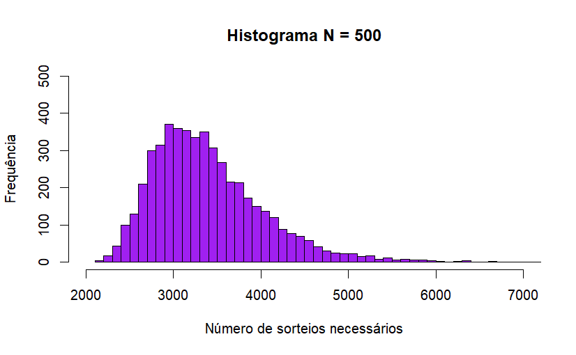

```r
h_emp_500 <- hist(A500,
     main = "Histograma N = 500",
     xlab = "Número de sorteios necessários",
     ylab = "Frequência",
     col = "purple",
     border = "black",
     breaks = 50,
     xlim = c(2000, 7000),
     ylim = c(0, 500))
```

```r
NA
NA
```

**Teoria: Cupom-coletor**

O valor esperado do $T$ (número de sorteios) é (resultados em(1)):

$$E(T) = nH(n)$$

onde o $H(n)$ é o n-ésimo número harmônico:

$$H(n) = 1 + \frac{1}{2}+...+\frac{1}{n-1}+\frac{1}{n}$$

Para valores grandes de $n$, pode ser aproximado como:

$$E(T) = nH(n) \approx n\ln{(n)} +\gamma n +\frac{1}{2}
+O\bigg(\frac{1}{n}\bigg)$$

onde $\gamma \approx 0.577215665$ é a constante Euler-Mascheroni e $O\bigg(\frac{1}{n}\bigg)$ representa um termo de erro que decresce proporcionalmente a $1/n$.

A variância de $T$ é (resultados em (1)):

$$Var(T) < n^2\bigg(\frac{\pi^2}{6}\bigg)$$

Assim, podemos encontrar o valor esperado e variância aproximados para cada n:

```r
#funçoes para calcular a medias e variancias teoricas
media <- function(n){
  return(n*log(n) + 0.577215665*n + 1/2 )
}
variancia <- function(n){
  return((n^2)*(pi^2)/6)
}
```

```r
#Tabela de medias e variancias aprox. (Teorica)
medias_real <- c(media(50), media(100), media(200), media(500))
variancias_real <- c(variancia(50), variancia(100), variancia(200), variancia(500))

tabela_real <- data.frame(
  N = Num,
  Média = round(medias_real, 2),
  Variância = round(variancias_real, 2)
)

print(tabela_real)
```

| N | Média | Variância |
| --- | --- | --- |
| 50 | 224.96 | 4112.34 |
| 100 | 518.74 | 16449.34 |
| 200 | 1175.61 | 65797.36 |
| 500 | 3396.41 | 411233.52 |

Para mais detalhes, fazemos o teste-t de student para a média empírca com a média real:

```r
t.test(A50, mu = media(50))
```

```
    One Sample t-test

data:  A50
t = 0.19822, df = 4999, p-value = 0.8429
alternative hypothesis: true mean is not equal to 224.9619
95 percent confidence interval:
 223.4037 226.8707
sample estimates:
mean of x
 225.1372
```

```r
t.test(A100, mu = media(100))
```

```
    One Sample t-test

data:  A100
t = 0.76535, df = 4999, p-value = 0.4441
alternative hypothesis: true mean is not equal to 518.7386
95 percent confidence interval:
 516.6174 523.5766
sample estimates:
mean of x
  520.097
```

```r
t.test(A200, mu = media(200))
```

```
    One Sample t-test

data:  A200
t = 1.656, df = 4999, p-value = 0.09779
alternative hypothesis: true mean is not equal to 1175.607
95 percent confidence interval:
 1174.496 1188.803
sample estimates:
mean of x
 1181.649
```

```r
t.test(A500, mu = media(500))
```

```
    One Sample t-test

data:  A500
t = 0.10919, df = 4999, p-value = 0.9131
alternative hypothesis: true mean is not equal to 3396.412
95 percent confidence interval:
 3379.544 3415.270
sample estimates:
mean of x
 3397.407
```

**Empírico x Teórico**

Podemos comparar os resultados obtidos empiricamente e os teóricos:

```r
#tabela com empirico e teorico
tabela_final <- data.frame(
  N = Num,
  Média_emp = round(medias_emp, 2),
  Média_teo = round(medias_real, 2),
  Variância_emp = round(variancias_emp, 2),
  Variância_teo = round(variancias_real, 2)

)
print(tabela_final)
```

| N | Média_emp | Média_teo | Variância_emp | Variância_teo |
| --- | --- | --- | --- | --- |
| 50 | 225.14 | 224.96 | 3909.20 | 4112.34 |
| 100 | 520.10 | 518.74 | 15751.10 | 16449.34 |
| 200 | 1181.65 | 1175.61 | 66575.11 | 65797.36 |
| 500 | 3397.41 | 3396.41 | 415122.04 | 411233.52 |

Encontramos também o erro absoluto:

```r
erro_media <- abs(medias_emp - medias_real)
erro_variancia <- abs(variancias_emp - variancias_real)

tabela_erro <- data.frame(
  N = Num,
  Médias_erro = erro_media,
  Variâncias_erro = erro_variancia
)
print(tabela_erro)
```

| N | Médias_erro | Variâncias_erro |
| --- | --- | --- |
| 50 | 0.1752665 | 203.1346 |
| 100 | 1.3584149 | 698.2365 |
| 200 | 6.0425937 | 777.7489 |
| 500 | 0.9949183 | 3888.5250 |

**Paradóxo do aniversário**

Neste problema, em grupo de $k$ indivíduos aleatórios, queremos encontrar a probabilidade de duas pessoas ter a mesma data de aniversário.

**Simulação: Paradóxo do aniversário**

Fixe $N = 365$. Para cada $k \in [2, 60]$ pessoas será feito um sorteio com reposição de 1 até $N$, $k$ vezes. Se tiver um item já observado, o sorteio conta como sucesso. Se não, fracasso. A variável de interesse é um indicador booleano se foi sucesso ou fracasso no sorteio.

```r
ParAni <- function(N, k){
  aux <- c()#vetor auxiliar para armazenar as datas sorteadas
  bool <- FALSE# booleano para ver se foi sucesso ou fracasso
  for(i in 1:k){ #loop para sortear as datas k vezes
    x <- sample(1:N, 1) #sorteio de uma data, de 1 até N=365
    if(x %in% aux){ #verifica se houve datas repetidas(colisão)
      bool <- TRUE #booleano torna true=sucesso
      break #termina as iteraçoes
    }
    else{
      aux <- c(aux, x)#se não, adiciona a data no vetor aux
    }

  }
  return(bool)#retorna o booleano
}
```

Faremos a simulação com $N = 365$ fixo, para diferentes $k$ :

```r
N <- 365
ParAni(N, 2)#k=2
```

```
[1] FALSE
```

```r
ParAni(N, 20)#k=20
```

```
[1] TRUE
```

```r
ParAni(N, 350)#k=350
```

```
[1] TRUE
```

Para cada $k \in [2:60]$, realizaremos $M= 10000$ simulações:

```r
repetidor <- function(k, M){
 aux <- list() #lista para armazenar os vetores
for(i in 2:k){ #para cada k, sera feito os loops
  vetor <- c() #vetor para armazenar os booleanos
  for(l in 1:M){
   x <- ParAni(N = 365, i) #sorteios
   vetor <- c(vetor, x) #adiciona o novo bool no vetor
  }
  aux <- c(aux, list(vetor)) #adiciona o vetor na lsta
  }
return(aux)#retorna a lista
 }
```

```r
k <- 60
M <- 10000
PA_60 <- repetidor(k, M)
```

Vamos encontrar a frequência de sucesso(colisão) para cada $k$ :

```r
f <- function(lista, M){
n <- length(lista)
contagem_true <- c()#vetor para armazenar quantos true tem por k
for(i in 1:n){
  true_count <- sum(unlist(lista[[i]]) %in% TRUE, na.rm = TRUE)
  contagem_true <- c(contagem_true, true_count)
  }
porc_true <- (contagem_true/M)*100 #porcentagem da taxa de sucesso
return(porc_true)
}

x <- f(PA_60, M)
```

Para visualizar melhor, faremos uma tabela e um gráfico com os dados obtidos experimentalmente:

```r
tabela_freq <- data.frame(
  N = 2:k,
  f_sucesso = x
)
print(tabela_freq)
```

| N | f_sucesso |
| --- | --- |
| 2 | 0.25 |
| 3 | 0.76 |
| 4 | 1.60 |
| 5 | 2.78 |
| 6 | 3.95 |
| 7 | 5.92 |
| 8 | 7.55 |
| 9 | 8.81 |
| 10 | 11.28 |
| 11 | 14.41 |

[output cut: 49 more lines]

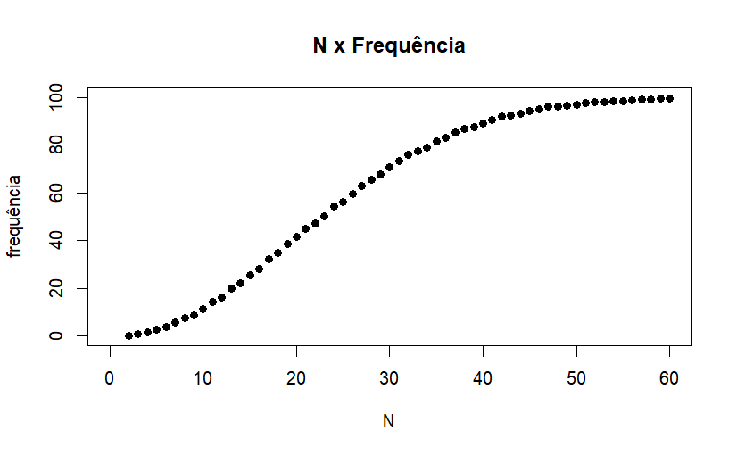

```r
t_ani_emp <- plot(tabela_freq$N, tabela_freq$f_sucesso,
     main = "N x Frequência",
     xlab = "N",
     ylab = "frequência",
     col = "black",
     pch = 16,
     cex = 1,
     type = "p",
     xlim = c(0, 60),
     ylim = c(0, 100)
)
```

**Teoria: Paradoxo do Aniversário**

Para calcular a probabilidade de $n$ pessoas em uma sala , em que pelo menos duas pessoas tenham o mesmo aniverário, calculamos a probabilidade do complementar, ou seja, a probabilidade de que $n$ pessoas não tenham o mesmo aniversário(referencias em 2):

$\bar{p}(n) = 1\cdot \bigg(1 - \frac{1}{365}\bigg)\cdot \bigg(1 - \frac{2}{365}\bigg)\cdot\cdot\cdot \bigg(1 - \frac{n-1}{365}\bigg) = \frac{365!}{365^n (365-n)!}$

Com isso, encontramos a probabilidade desejada, de $n$ pessoas, pelo menos duas pessoas terem o mesmo aniversário:

$p(n) = 1 - \bar{p}(n)$

Fazemos então o código para encontrar as probabilidades:

```r
f_prob_an <- function(n){
  if(n > 365){
    return(1) #se n maior que 365, a probabilidade é 1
  }
  else if (n < 2){
    return(0) #se n menor que 2,  a probabilidade é 0
  }
  else {
    prob_diferentes <- 1
    for (i in 1:(n-1)) {
      prob_diferentes <- prob_diferentes * (365 - i) / 365
    }
    # Probabilidade de pelo menos 2 terem o mesmo aniversário
    return(1 - prob_diferentes)
  }
}
```

```r
k = 60
vetor_aniv <- c()
for(i in 2:k){
  y <- f_prob_an(i)
  vetor_aniv <- c(vetor_aniv, y)
}

tabela_freq_real <- data.frame(
  N = 2:k,
  f_sucesso_real = vetor_aniv *100
)
print(tabela_freq_real)
```

| N | f_sucesso_real |
| --- | --- |
| 2 | 0.2739726 |
| 3 | 0.8204166 |
| 4 | 1.6355912 |
| 5 | 2.7135574 |
| 6 | 4.0462484 |
| 7 | 5.6235703 |
| 8 | 7.4335292 |
| 9 | 9.4623834 |
| 10 | 11.6948178 |
| 11 | 14.1141378 |

[output cut: 49 more lines]

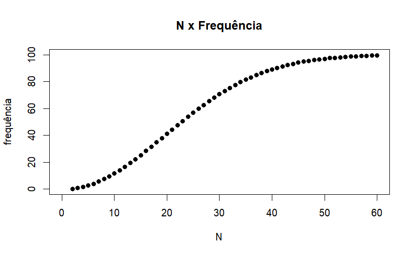

```r
t_ani_real <- plot(tabela_freq_real$N, tabela_freq_real$f_sucesso_real,
     main = "N x Frequência",
     xlab = "N",
     ylab = "frequência",
     col = "black",
     pch = 16,
     cex = 1,
     type = "p",
     xlim = c(0, 60),
     ylim = c(0, 100)
)
```

**Empírico x teórico**

Podemos comparar os resultados obtidos empiricamente e os teóricos, com tabela e gráfico:

```r
tabela_freq_geral <- data.frame(
  N = 2:k,
  f_sucesso_real = vetor_aniv *100,
  f_suceeso_emp = x
)
print(tabela_freq_geral)
```

| N | f_sucesso_real | f_suceeso_emp |
| --- | --- | --- |
| 2 | 0.2739726 | 0.25 |
| 3 | 0.8204166 | 0.76 |
| 4 | 1.6355912 | 1.60 |
| 5 | 2.7135574 | 2.78 |
| 6 | 4.0462484 | 3.95 |
| 7 | 5.6235703 | 5.92 |
| 8 | 7.4335292 | 7.55 |
| 9 | 9.4623834 | 8.81 |
| 10 | 11.6948178 | 11.28 |
| 11 | 14.1141378 | 14.41 |

[output cut: 49 more lines]

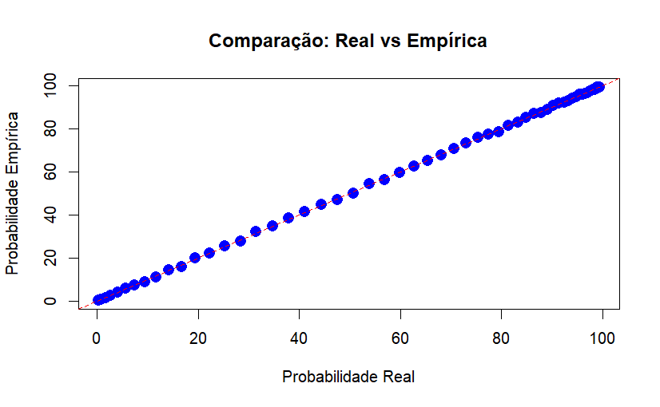

```r
plot(tabela_freq_real$f_sucesso_real, tabela_freq$f_sucesso,
     xlab = "Probabilidade Real",
     ylab = "Probabilidade Empírica",
     main = "Comparação: Real vs Empírica",
     pch = 16, col = "blue", cex = 1.5)
abline(a = 0, b = 1, col = "red", lty = 2)
```

**Conclusões**

Percebemos no projeto que, simulando um problema em algoritmo e obter uma grande quantidade de amostras independentes, podemos encontrar médias, variâncias ou probabilidades empíricas que tem boa precisão. Esse método é chamado de Método do Monte Carlo, que explica que ao obter amostras aleatórias de grande número, este tende ao parâmetro desejado, ou seja:

$$\hat{\theta_n} = \frac{1}{n}\sum{}g(X_i) \to \theta$$

quase certamente, pela Lei dos Grandes números.

Assim, concluímos que é possível obter respostas de problemas probabilísticos analicamente, ao simular o problema em códigos e obter várias amostras aleatórias, conforme foi feito no projeto.

**Referências**

1. https://towardsdatascience.com/coupon-collectors-problem-a-probability-masterpiece-1d5aed4af439/
2. https://pt.wikipedia.org/wiki/Paradoxo_do_anivers%C3%A1rio